# Анализ мощности

## Мы рассмотрим

- Мощность статистического теста
- Способы оценки величины эффекта
- *A priori* анализ мощности
- Использование симуляций для анализа мощности
- Как влиять на мощность тестов

## Мощность статистического теста

## Типы ошибок при проверке гипотез

[output not shown]

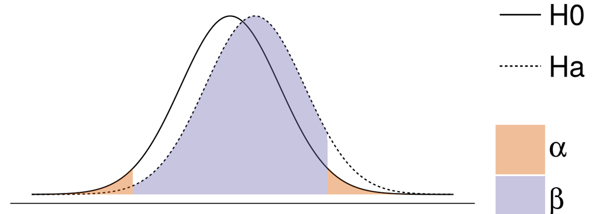

## Мощность статистического теста

[output not shown]

### Мощность статистического теста —

вероятность найти различия там, где они есть \(Power = 1 - \beta\)

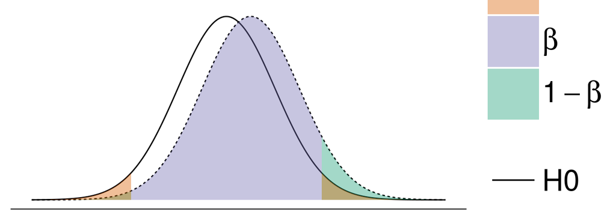

## Анализ мощности

- Какой нужен объем выборки, чтобы найти различия?
- Какой величины различия мы можем найти при определенном объеме выборки?

## Величина эффекта

## Величина эффекта

\[\frac{\bar \mu_1 - \bar \mu_2}{\sigma}\]

## Величина эффекта

\[\frac{\bar \mu_1 - \bar \mu_2}{\sigma}\]

- \(\sigma\) — среднеквадратичное стандартное отклонение

\(d = \frac {|\bar x_1 - \bar x_2|} { \sqrt {\frac {s_1^2 + s_2^2 } {2} }}\)

## Величина эффекта

\[\frac{\bar \mu_1 - \bar \mu_2}{\sigma}\]

- \(\sigma\) — среднеквадратичное стандартное отклонение

\(d = \frac {|\bar x_1 - \bar x_2|} { \sqrt {\frac {s_1^2 + s_2^2 } {2} }}\)

- \(\sigma\) — обобщенное стандартное отклонение

\(d = \frac {|\bar x _{1} - \bar x _{2}|} { \sqrt {\frac {(n_{1} - 1) s_1^2 + (n_{2} - 1) s_{2}^2 } {n_{1} + n_{2} - 2} } }\)

## Как оценить ожидаемую величину эффекта?

\[\frac{\bar \mu_1 - \bar \mu_2}{\sigma}\]

Варианты:

- Пилотные исследования
- Литература
- Общебиологические знания
- Технические требования

## Условные уровни величины эффекта

Сильные, умеренные и слабые эффекты (Cohen, 1982)

```r
library(pwr)
cohen.ES(test = "t", size = "large")
```

```
##
##      Conventional effect size from Cohen (1982)
##
##            test = t
##            size = large
##     effect.size = 0.8
```

## Задача

Рассчитайте величину умеренных и слабых эффектов для t-критерия при помощи функции `cohen.ES()`

## Решение

```r
# умеренный
cohen.ES(test = "t", size = "medium")
```

```
##
##      Conventional effect size from Cohen (1982)
##
##            test = t
##            size = medium
##     effect.size = 0.5
```

```r
# слабый
cohen.ES(test = "t")
```

```
##
##      Conventional effect size from Cohen (1982)
##
##            test = t
##            size = small
##     effect.size = 0.2
```

## Задача

Исследователи хотят проверить, что у крыс на богатой жирами диете ген "гормона голода" лептина будет даун-регулироваться в 5 раз.

Т.е. ожидаемая разница логарифмов экспрессии между опытом и контролем будет примерно \(log2(1) - log2(5) = -2.32\)

Стандартное отклонение этих различий по пилотным данным 1.2

Рассчитайте величину эффекта

Скажите, это будет слабый или сильный эффект?

## Решение

```r
abs(-2.32) / 1.2
```

```
## [1] 1.93
```

## Расчет величины эффекта по данным пилотного исследования

## Величина эффекта по данным пилотного исследования

Представьте себе, что у нас есть результаты пилотного исследования. Мы хотим знать, различается ли уровень клеточной активности у пациентов в зависимости от того, наступила ли ремиссия. (Данные из кн. Freeman 1987).

```r
library(readxl)
rem <- read_excel(path = "data/remission.xlsx", sheet = 1)
head(rem)
```

```
## # A tibble: 6 × 3
##      LI     m     r
##   <dbl> <dbl> <dbl>
## 1   0.4     1     0
## 2   0.4     1     0
## 3   0.5     1     0
## 4   0.5     1     0
## 5   0.6     1     0
## 6   0.6     1     0
```

Это данные о больных раком:

- `LI` — мера клеточной активности
- `r` — индикатор того наступила ли ремиссия (1 — да, 0 — нет)

## Убедимся, что данные открылись правильно

```r
str(rem)
```

```
## Classes 'tbl_df', 'tbl' and 'data.frame':    27 obs. of  3 variables:
##  $ LI: num  0.4 0.4 0.5 0.5 0.6 0.6 0.6 0.7 0.7 0.7 ...
##  $ m : num  1 1 1 1 1 1 1 1 1 1 ...
##  $ r : num  0 0 0 0 0 0 0 0 0 0 ...
```

```r
rem$r <- factor(rem$r, levels = c(0, 1), labels = c("no", "yes"))
```

```r
## Пропущенные значения
colSums(is.na(rem))
```

```
## LI  m  r
##  0  0  0
```

```r
## Объем выборки
table(rem$r)
```

```
##
##  no yes
##  18   9
```

## Задача

Визуализируйте при помощи бокс-плотов различия клеточной активности в двух группах пациентов.

Используйте геом `geom_boxplot()`

Обозначьте группу при помощи заливки.

Подпишите оси при помощи элемента `labs()`

## Решение

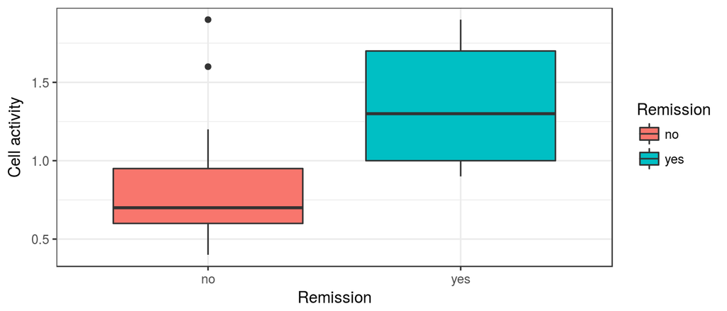

```r
library(ggplot2)
ggplot(rem, aes(x = r, y = LI)) +
  geom_boxplot(aes(fill = r)) +
  labs(x = "Remission", y = "Cell activity", fill = "Remission")
```

## Давайте оценим величину эффекта

```r
library(effsize)
effect <- cohen.d(rem$LI, rem$r)
effect
```

```
##
## Cohen's d
##
## d estimate: -1.32 (large)
## 95 percent confidence interval:
##    inf    sup
## -2.235 -0.398
```

## Задача

Посмотрите на структуру объекта `effect` при помощи функции `str()` и добудьте из него средствами R значение величины эффекта

## Решение

```r
str(effect)
```

```
## List of 6
##  $ method    : chr "Cohen's d"
##  $ name      : chr "d"
##  $ estimate  : Named num -1.32
##   ..- attr(*, "names")= chr "no"
##  $ conf.int  : Named num [1:2] -2.235 -0.398
##   ..- attr(*, "names")= chr [1:2] "inf" "sup"
##  $ conf.level: num 0.95
##  $ magnitude : Ord.factor w/ 4 levels "negligible"<"small"<..: 4
##  - attr(*, "class")= chr "effsize"
```

```r
effect$estimate
```

```
##    no
## -1.32
```

## Анализ мощности в R

## Анализ мощности t-критерия в R

Давайте рассчитаем, какой будет нужен объем выборки, чтобы показать различия между группами с вероятностью 0.8 (т.е. чтобы мощность теста была 80%)

```r
library(pwr)
pwr.t.test(n = NULL, d = effect$estimate, power = 0.8,
           sig.level = 0.05, type = "two.sample",
           alternative = "two.sided")
```

```
##
##      Two-sample t test power calculation
##
##               n = 10.1
##               d = 1.32
##       sig.level = 0.05
##           power = 0.8
##     alternative = two.sided
##
## NOTE: n is number in *each* group
```

## Задача

Экстрагируйте из результатов `pwr.t.test()` величину объема выборки

## Решение

```r
R1 <- pwr.t.test(n = NULL, d = effect$estimate, power = 0.8,
                 sig.level = 0.05, type = "two.sample",
                 alternative = "two.sided")
str(R1)
```

```
## List of 7
##  $ n          : num 10.1
##  $ d          : Named num 1.32
##   ..- attr(*, "names")= chr "no"
##  $ sig.level  : num 0.05
##  $ power      : num 0.8
##  $ alternative: chr "two.sided"
##  $ note       : chr "n is number in *each* group"
##  $ method     : chr "Two-sample t test power calculation"
##  - attr(*, "class")= chr "power.htest"
```

```r
R1$n
```

```
## [1] 10.1
```

Округляем в большую сторону

```r
ceiling(R1$n)
```

```
## [1] 11
```

## Задача

А если группы будут разного размера?

Пациентов с ремиссией всего 5.

Сколько нужно обследовать пациентов без ремиссии, чтобы обнаружить различия клеточной активности между группами?

Используйте функцию `pwr.t2n.test`

## Решение

```r
R2 <- pwr.t2n.test(n1 = 5, n2 = NULL, d = effect$estimate,
                   power = 0.8, sig.level = 0.05,
                   alternative = "two.sided")
ceiling(R2$n2)
```

```
## [1] 68
```

## Другой пример

Данные анализа мочи. В некоторых пробах обнаружены кристаллы оксалата кальция. (Данные из сборника датасетов Andrews Herzberg 1985)

Представим, что это данные пилотного исследования.

```r
ur <- read_excel(path = "data/urine.xlsx", sheet = 1)
head(ur)
```

```
## # A tibble: 6 × 7
##       r gravity    ph  osmo  cond  urea  calc
##   <dbl>   <dbl> <dbl> <dbl> <dbl> <dbl> <dbl>
## 1     0    1.02  4.91   725    NA   443  2.45
## 2     0    1.02  5.74   577  20.0   296  4.49
## 3     0    1.01  7.20   321  14.9   101  2.36
## 4     0    1.01  5.51   408  12.6   224  2.15
## 5     0    1.00  6.52   187   7.5    91  1.16
## 6     0    1.02  5.27   668  25.3   252  3.34
```

- `r` — индикатор присутствия кристаллов оксалата кальция
- `calc` — концентрация кальция

## Убедимся, что данные открылись правильно

```r
str(ur)
```

```
## Classes 'tbl_df', 'tbl' and 'data.frame':    79 obs. of  7 variables:
##  $ r      : num  0 0 0 0 0 0 0 0 0 0 ...
##  $ gravity: num  1.02 1.02 1.01 1.01 1 ...
##  $ ph     : num  4.91 5.74 7.2 5.51 6.52 5.27 5.62 5.67 5.41 6.13 ...
##  $ osmo   : num  725 577 321 408 187 ...
##  $ cond   : num  NA 20 14.9 12.6 7.5 25.3 17.4 35.9 21.9 25.7 ...
##  $ urea   : num  443 296 101 224 91 252 195 550 170 382 ...
##  $ calc   : num  2.45 4.49 2.36 2.15 1.16 3.34 1.4 8.48 1.16 2.21 ...
```

```r
ur$r <- factor(ur$r, levels = c(0, 1),
               labels = c("absent", "present"))
```

```r
## Пропущенные значения
colSums(is.na(ur))
```

```
##       r gravity      ph    osmo    cond    urea    calc
##       0       0       0       1       1       0       0
```

```r
## Объем выборки
table(ur$r)
```

```
##
##  absent present
##      45      34
```

## Задача

Постройте гистограмму распределения концентрации кальция. Заливкой обозначьте присутствие кристаллов оксалата кальция в пробе.

## Решение

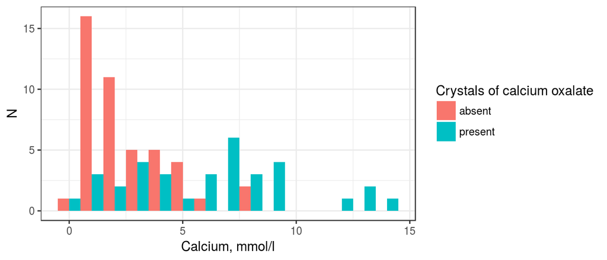

```r
ggplot(ur, aes(x = calc, fill = r)) +
  geom_histogram(binwidth = 1, position = "dodge") +
  labs(x = "Calcium, mmol/l", y = "N", fill = "Crystals of calcium oxalate")
```

## Задача

Сколько нужно анализов, чтобы показать, что содержание кальция в этих пробах достоверно отличается при уровне значимости \(\alpha = 0.001\)?

- При равном объеме выборок
- Если будет только 16 проб с кристаллами оксалата кальция

## Решение

```r
effect_ur <- cohen.d(ur$calc, ur$r)
R3 <- pwr.t.test(n = NULL, d = abs(effect_ur$estimate),
                 power = 0.8, sig.level = 0.001,
                 type = "two.sample", alternative = "two.sided")
ceiling(R3$n)
```

```
## [1] 24
```

```r
R4 <- pwr.t2n.test(n1 = 16, n2 = NULL, d = effect_ur$estimate,
                   power = 0.8, sig.level = 0.001,
                   alternative = "two.sided")
ceiling(R4$n2)
```

```
## [1] 43
```

## Анализ мощности t-критерия при помощи симуляции

## Анализ мощности t-критерия при помощи симуляции

При помощи простой симуляции можно проверить, будет ли достаточно 24 наблюдений в группе

Сначала готовим данные

```r
# средние значения из пилотного исследования
mu <- tapply(X = ur$calc, INDEX = ur$r, FUN = mean)

# обобщенное стандартное отклонение sigma в пилотном исследовании
ns <- table(ur$r)
var <- tapply(X = ur$calc, INDEX = ur$r, FUN = var)
sigma <- sqrt(((ns[1] - 1) * var[1] + (ns[2] - 1) * var[2])/(length(ur$r) - 2))

n <- 24 # проверяемое значение объема выборки
reps <- 1000 # число повторов в симуляции
```

## ВАРИАНТ 1 - Используем цикл

```r
pvals <- rep(NA, reps) # Место для результата
set.seed(42) # зерно генератора случайных чисел

# в цикле  многократно симулируем данные
for (i in 1:reps){
  # генерируем две случайные выборки
  # из нормального распределения
  x1 <- rnorm(n, mu[1], sigma)
  x2 <- rnorm(n, mu[2], sigma)
  # сравниваем их средние значения t-критерием
  t_res <- t.test(x = x1, y = x2)
  # добываем уровень значимости
  pvals[i] <- t_res$p.value
}
# Доля уровней значимости меньше критического уровня (здесь p < 0.001)
mean(pvals < 0.001)
```

```
## [1] 0.818
```

## ВАРИАНТ 2 - Используем `replicate()`

```r
# функция, генерирующая одну симуляцию
# n - объем выборки
my_sim <- function(n) {
  x1 <- rnorm(n, mu[1], sigma)
  x2 <- rnorm(n, mu[2], sigma)
  t_res <- t.test(x = x1, y = x2)
  return(t_res$p.value)
}
# my_sim(24) # пример употребления - одна симуляция

# Повторяем симуляцию 1000 раз
set.seed(42)
pvals <- replicate(1000, my_sim(24))
mean(pvals < 0.001)
```

```
## [1] 0.818
```

## Как проверить несколько возможных объемов выборки?

Вариант 2 легче масштабируется.

Достаточно дописать еще одну функцию, и мы сможем оценить мощность теста при разных объемах выборки.

```r
# функция, возвращающая долю симуляций с p < 0.001
# x - объем выборки
my_sim_range <- function(x){
  pvals <- replicate(1000, my_sim(x))
  pw <- mean(pvals < 0.001)
  return(pw)
}
set.seed(42)
sapply(X = 20:25, FUN = my_sim_range)
```

```
## [1] 0.666 0.735 0.730 0.780 0.787 0.844
```

## Задание

По итогам предыдущей симуляции постройте кривую зависимости мощности от объема выборки (от 5 до 35)

## Решение

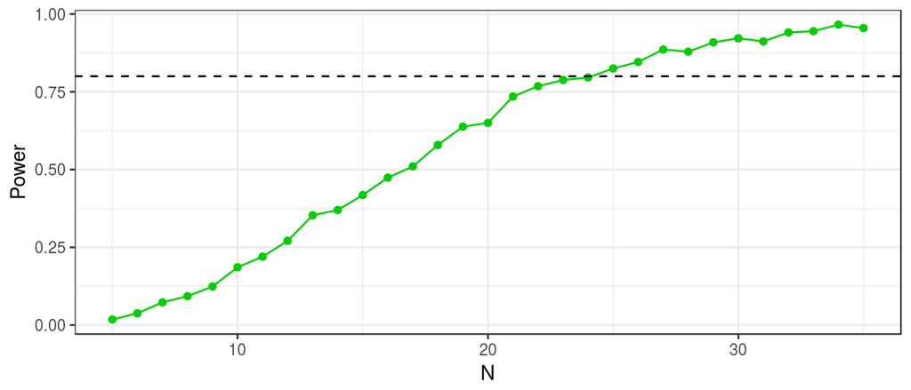

```r
set.seed(42)
sim <- sapply(X = 5:35, FUN = my_sim_range)

pwr_dat <- data.frame(N = 5:35, Power = sim)
ggplot(pwr_dat, aes(x = N, y = Power)) +
  geom_point(colour = "green3") +
  geom_line(aes(group = 1), colour = "green3") +
  geom_hline(yintercept = 0.8, linetype = "dashed")
```

## Задание

При помощи симуляций проведите анализ мощности для данных о клеточной активности у больных раком

Постройте кривую зависимости мощности теста от объема выборки

## Решение: подготовка

```r
# средние значения из пилотного исследования
mu <- tapply(X = rem$LI, INDEX = rem$r, FUN = mean)

# обобщенное стандартное отклонение sigma в пилотном исследовании
ns <- table(rem$r)
var <- tapply(X = rem$LI, INDEX = rem$r, FUN = var)
sigma <- sqrt(((ns[1] - 1) * var[1] + (ns[2] - 1) * var[2])/(length(ur$r) - 2))

reps <- 1000 # число повторов в симуляции
```

## Решение: симуляция

```r
# функция, генерирующая одну симуляцию
my_sim <- function(n) {
  x1 <- rnorm(n, mu[1], sigma)
  x2 <- rnorm(n, mu[2], sigma)
  t_res <- t.test(x = x1, y = x2)
  return(t_res$p.value)
}

# функция, возвращающая долю симуляций со значением p меньше критического
my_sim_range <- function(x){
  pvals <- replicate(1000, my_sim(x))
  fraction <- mean(pvals < 0.001)
  return(fraction)
}

set.seed(42)
sim <- sapply(X = 5:15, FUN = my_sim_range)
```

## Решение: график зависимости мощности от объема выборки

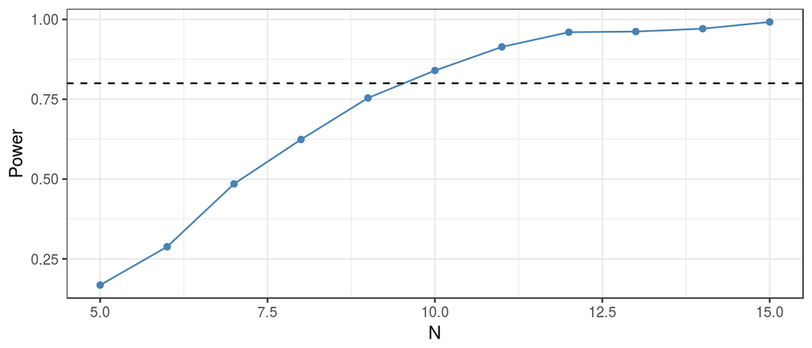

```r
pwr_dat <- data.frame(N = 5:15, Power = sim)
ggplot(pwr_dat, aes(x = N, y = Power)) +
  geom_point(colour = "steelblue") +
  geom_line(aes(group = 1), colour = "steelblue") +
  geom_hline(yintercept = 0.8, linetype = "dashed")
```

## Как влиять на мощность теста?

## Мощность зависит

- от объема выборки
- от величины эффекта
- от уровня значимости

## Чем больше объем выборки—тем больше мощность

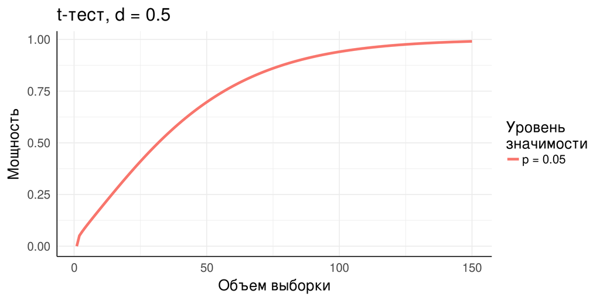

## Чем больше уровень значимости—тем больше мощность

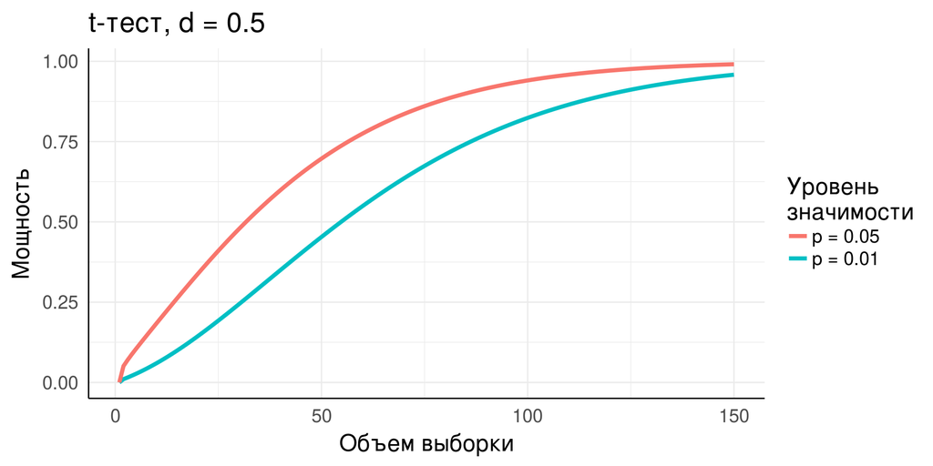

## Чем больше величина различий—тем больше мощность

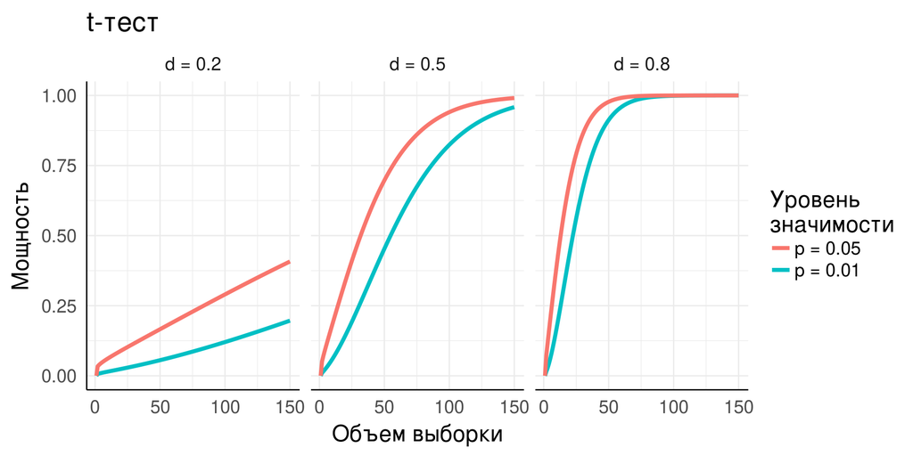

## Скажите

Какие из факторов, влияющих на мощность теста, мы **не можем** контролировать?

- Мы не можем контролировать внешние факторы
- величину эффекта (\(ES\))
- фоновую изменчивость (\(\sigma^2\))

Каким образом можно повлиять на мощность теста?

- Мощность теста можно регулировать, если
- изменить число повторностей
- выбрать другой уровень значимости (\(\alpha\))
- определиться, какие эффекты действительно важны (\(ES\))

## Take home messages

- Способность выявлять различия зависит
- от объема выборки,
- от уровня значимости
- от величины эффекта

## Дополнительные ресурсы

- Quinn, Keough, 2002, pp. 164-170
- [OpenIntro Statistics](http://www.openintro.org)